# Data 624 Project 2

# 5 Random Forest Model

Random forests are a modification of bagging that builds a large collection of de-correlated trees [1]. They are considered to belong in the category of non-parametric models since the number of parameters grows with the size of the training set. They are considered to be an improvement to the use of CART (Classification and Regression Tree) models because they do not suffer from some of the problems associated with CART models, such as the fact that CART models are unstable: small changes to the structure of the input data can have large effects on the CART model [2]. Random forests are designed to be low-variance estimators.

Random forests are based on the basic idea of aggregating uncorrelated sets of predictors, since one way to reduce the variance of an estimate is to average several estimates together [2]. A random forest trains a randomly chosen set of input variables over a randomly chosen subset of the data, and aggregates together several such trees to produce an overall estimator. Random forests have proven to be quite successful in a variety of real-world applications and often are seen to generalize very well to unseen real-world data.

```r
# Split the training data into a portion that is withheld from the model and used to evaluate
# the model.

set.seed(123)
sample = sample.split(training$Percent.Below.Poverty.Line, SplitRatio = .75)
training_forest = subset(training, sample == TRUE)
training_forest
```

|  | Percent.Limited.English.Households | Percent.With.Broadband | Percent.Occupied.Single.Family.Homes | Percent.In.Service.Industry | Percent.STEM.education | Percent.Computer.in.Household | Percent.Smartphone.In.Household | Percent.No.of.Internet.Subscriptions | Employment.Rate | Median.Annual.Income | Percent.in.Public.School | Percent.Foreign.Born | White | Black | Native | Asian | Other | Two.or.more | Population | Median.Age | Percent.male | Percent.Less.Than.High.School | Percent.High.School | Percent.Some.College | Percent.Bachelors | Population.Graduate | Percent.Below.Poverty.Line | Median.Monthly.Housing.Costs |
| --- | --- | --- | --- | --- | --- | --- | --- | --- | --- | --- | --- | --- | --- | --- | --- | --- | --- | --- | --- | --- | --- | --- | --- | --- | --- | --- | --- | --- |
| 1 | 1.0 | 82.2 | 85.0 | 68.3 | 28.8 | 86.1 | 77.3 | 78.5 | 52.9 | 48123 | 86.7 | 0.03592806 | 0.6795672 | 0.268212279 | 0.005165601 | 0.013725430 | 0.013807486 | 0.01726038 | 4874747 | 38.9 | 46.90 | 9.4 | 31.1 | 21.4 | 16.0 | 9.6 | 29.1 | 734 |
| 3 | 4.0 | 87.7 | 82.3 | 68.2 | 32.5 | 92.2 | 83.3 | 86.0 | 56.1 | 56581 | 88.8 | 0.15183776 | 0.7756852 | 0.043848797 | 0.045319522 | 0.033139688 | 0.061692751 | 0.03014907 | 7016270 | 37.7 | 49.40 | 7.4 | 24.1 | 25.0 | 18.3 | 11.0 | 24.6 | 1015 |
| 6 | 2.7 | 90.9 | 83.4 | 70.1 | 39.3 | 94.2 | 86.1 | 88.6 | 64.6 | 69117 | 88.4 | 0.10892523 | 0.8418700 | 0.040918441 | 0.010128489 | 0.031968268 | 0.039090954 | 0.02884387 | 5607154 | 36.8 | 50.60 | 5.0 | 21.3 | 20.9 | 26.0 | 15.2 | 21.0 | 1300 |
| 7 | 5.3 | 89.6 | 83.8 | 67.2 | 36.1 | 90.9 | 81.1 | 85.9 | 61.4 | 74168 | 80.0 | 0.17339947 | 0.7588833 | 0.106064238 | 0.003140307 | 0.045684391 | 0.053334221 | 0.02553325 | 3588184 | 40.9 | 47.65 | 5.5 | 27.1 | 16.5 | 21.4 | 17.3 | 20.1 | 1390 |
| 9 | 3.6 | 84.1 | 25.7 | 66.4 | 49.4 | 91.9 | 86.5 | 82.8 | 65.3 | 82372 | 58.1 | 0.17202826 | 0.4100108 | 0.458548760 | 0.002435257 | 0.041066498 | 0.057806367 | 0.02568259 | 693972 | 34.0 | 45.10 | 5.5 | 17.2 | 12.5 | 23.9 | 33.4 | 19.4 | 1641 |
| 10 | 6.9 | 85.6 | 73.7 | 71.9 | 31.7 | 91.9 | 82.8 | 83.4 | 54.9 | 52594 | 82.1 | 0.26373535 | 0.7514303 | 0.161763405 | 0.003032491 | 0.028024961 | 0.028689503 | 0.02217709 | 20984400 | 42.0 | 47.80 | 6.9 | 28.8 | 19.9 | 18.9 | 10.8 | 24.9 | 1047 |
| 12 | 5.5 | 88.3 | 72.8 | 72.5 | 34.8 | 91.3 | 83.1 | 84.8 | 59.0 | 77765 | 77.9 | 0.22854662 | 0.2501601 | 0.016382051 | 0.001864048 | 0.382223801 | 0.015044083 | 0.22636455 | 1427538 | 39.2 | 50.35 | 4.3 | 28.1 | 20.5 | 21.7 | 11.2 | 23.4 | 1585 |
| 13 | 2.1 | 88.3 | 90.4 | 65.2 | 33.2 | 91.3 | 79.8 | 83.1 | 59.2 | 52225 | 86.3 | 0.06259426 | 0.9004440 | 0.006608839 | 0.012574092 | 0.013461717 | 0.034417567 | 0.02706846 | 1716943 | 36.3 | 50.50 | 5.9 | 28.2 | 26.3 | 18.2 | 8.5 | 27.8 | 880 |
| 14 | 4.5 | 88.0 | 79.6 | 68.3 | 32.6 | 90.3 | 82.0 | 84.0 | 60.8 | 62992 | 81.7 | 0.16704535 | 0.7123805 | 0.142085825 | 0.002336349 | 0.054285795 | 0.062327337 | 0.02093255 | 12802023 | 38.0 | 48.35 | 6.0 | 26.1 | 20.6 | 21.0 | 13.4 | 23.4 | 1081 |
| 15 | 1.7 | 85.1 | 92.0 | 69.0 | 29.0 | 88.8 | 78.7 | 81.6 | 60.4 | 54181 | 83.6 | 0.05561369 | 0.8366656 | 0.093592025 | 0.001859508 | 0.022254395 | 0.018858322 | 0.02334442 | 6666818 | 37.7 | 48.60 | 7.7 | 32.7 | 20.2 | 17.0 | 9.8 | 26.5 | 815 |

[output cut: 29 more lines]

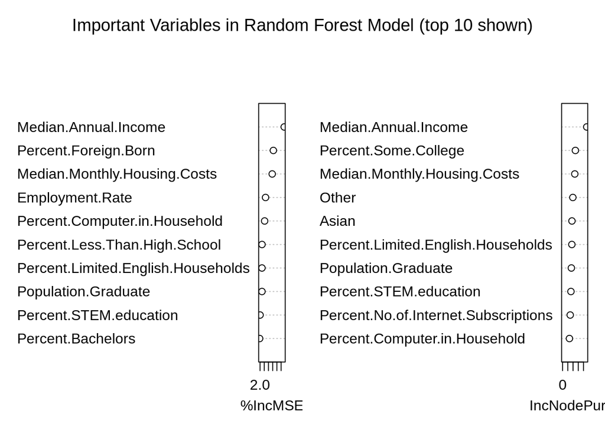

```r
test_forest = subset(training, sample == FALSE)

set.seed(123)
rfFit <- randomForest::randomForest(Percent.Below.Poverty.Line ~ ., data = training_forest, importance = TRUE,
                                    ntree = 100, keep.forest = TRUE)
model2 <- rfFit

varImpPlot(rfFit, n.var=10,
           main="Important Variables in Random Forest Model (top 10 shown)")
```

We now compute RMSE values for the Random Forest model on both the training and the test (withheld) portion of the data set.

```r
training_forest2 = dplyr::select(training_forest, -Percent.Below.Poverty.Line)
rfPred.train = predict(rfFit, training_forest2)
rmse.rf.train = rmse(training_forest$Percent.Below.Poverty.Line, rfPred.train)
r2.rf.train = R2(training_forest$Percent.Below.Poverty.Line, rfPred.train)
test_forest2 = dplyr::select(test_forest, -Percent.Below.Poverty.Line)
rfPred.test = predict(rfFit, test_forest2)
rmse.rf.test = rmse(test_forest$Percent.Below.Poverty.Line, rfPred.test)
r2.rf.test = R2(test_forest$Percent.Below.Poverty.Line, rfPred.test)
kable(data.frame(Model=c("Random Forest"), RMSE.train=c(rmse.rf.train), RSquared.train=c(r2.rf.train), RMSE.test=c(rmse.rf.test), RSquared.test=c(r2.rf.test)))
```

| Model | RMSE.train | RSquared.train | RMSE.test | RSquared.test |
| --- | --- | --- | --- | --- |
| Random Forest | 1.732264 | 0.9750761 | 1.708613 | 0.8485353 |

# 6 Neural Network Model

Neural Networks are a powerful nonlinear technique inspired by theories about how the human brain works [5]. Neural Networks can be classifiers (when the output variable is categorical) or regression (when the output variable is numeric). In this problem we use a regression artificial neural network (ANN) using the nnet package in R. Below we build and evaluate a Neural Network model of the regression problem.

```r
set.seed(123)
training_nn = training_forest2
training_nn_y = training_forest$Percent.Below.Poverty.Line
test_nn = test_forest2
test_nn_y = test_forest$Percent.Below.Poverty.Line

nnetFit <- nnet(training_nn, training_nn_y,
                size = 4,
                decay = 0.01,
                linout = TRUE,
                trace = FALSE,
                maxit = 500, # Iterations
                ## Number of parameters used by the model
                MaxNWts= 4 * (ncol(training_nn) + 1) + 5 + 1)
model3 <- nnetFit
nnetFit
```

```
## a 27-4-1 network with 117 weights
## options were - linear output units  decay=0.01
```

```r
rmse.nnet.train = rmse(training_nn_y, predict(nnetFit, training_nn))
r2.nnet.train = mean(cor(training_nn_y, training_nn)^2)
rmse.nnet.test = rmse(test_nn_y, predict(nnetFit, test_nn))
r2.nnet.test = mean(cor(test_nn_y, test_nn)^2)
kable(data.frame(Model=c("NeuralNet"), RMSE.train=c(rmse.nnet.train), RSquared.train=c(r2.nnet.train), RMSE.test=c(rmse.nnet.test), RSquared.test=c(r2.nnet.test)))
```

| Model | RMSE.train | RSquared.train | RMSE.test | RSquared.test |
| --- | --- | --- | --- | --- |
| NeuralNet | 5.997393 | 0.2709523 | 3.939332 | 0.3219012 |